# 📈 L4: Forecasting using univariate models

M-B5203E - Time Series, Analytics and Forecasting - 26-27

Anubhab Biswas

ISAAC, DACD, SUPSI

5th October, 2026

## Forecasting using statistical models

In this lecture, we will cover the following topics:

- Tidy workflow for time series forecasting
- Exponential smoothing models
- ARIMA models
- Practical forecasting session using *statsforecast* package.

**Resources**:

- [fpppy chapter 8](https://otexts.com/fpppy/08-exponential-smoothing.html)
- [fpppy chapter 9](https://otexts.com/fpppy/09-arima.html)

[figure not shown]

## Introduction

- Time series forecasting can be broken down into the following steps<sup>1</sup>:

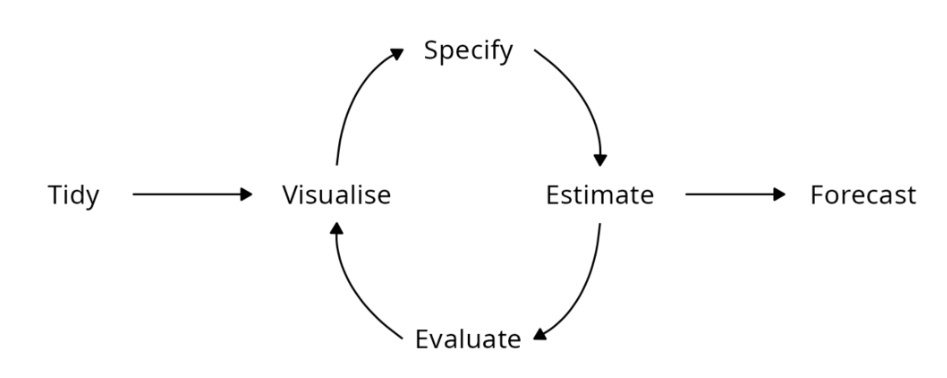

[^1]: [fppy chapter 5](https://otexts.com/fpppy/05-toolbox.html)

## Tidy workflow for forecasting

- *Tidy*: Data preparation and pre-processing in the correct format.
- *Visualize*: Plotting the data to identify patterns that will help to specify an appropriate model.
- *Specify*: Specifying the appropriate model for the data to produce forecasts.
- *Estimate*: Training the specified model on one part of the data.
- *Evaluate*: Checking the performance of the fitted model on the data using diagnostic tools.
- *Forecast*: Produce forecasts using this fitted model if it passes the diagnostic checks.

## Statistical models for forecasting

- In this lecture we are interested in the $\text{specify}\rightarrow \dots \rightarrow \text{forecast}$ part.
- Statistical models are widely used for doing this task.

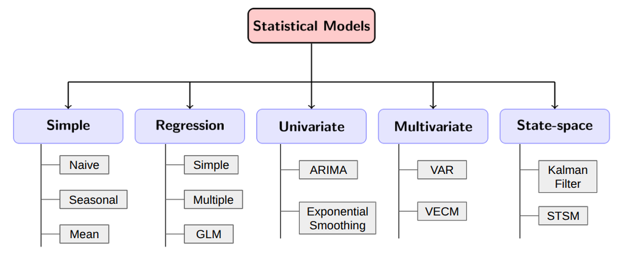

Statistical models for forecasting

- You have already learnt about the **Simple** models in previous lectures.
- Today we focus on the *Univariate* models.

## Univariate models for forecasting

- Among the univariate models for forecasting, we will mainly consider the following two types:
- *Exponential Smoothing models*
- *ARIMA models*
- These models are considered to be classical, and often (more than you would expect) provide very accurate forecasts if modelled correctly.
- In this lecture, we will learn how to produce forecasts with these two models by going through the tidy workflow for both.

## Exponential smoothing models (ETS)

- Introduced in the late 1950s by **Holt**, **Brown**, and **Winters** in their respective papers.
- Remember the simple models for forecasting?
- Two of them were **Naive** and **Mean** methods.
- These are two extreme cases:
  - **Naive** : $\hat{y}_{T+h|T} = y_T$ which assumes *only the recent observation* is *important*.
  - **Mean** : $\hat{y}_{T+h|T} = \frac{1}{T}\sum_{t=1}^T y_t$ which assumes *all the past observations* are *equally important*.
- Exponential smoothing is something in between these two extreme scenarios.

## Simple exponential smoothing (SES)

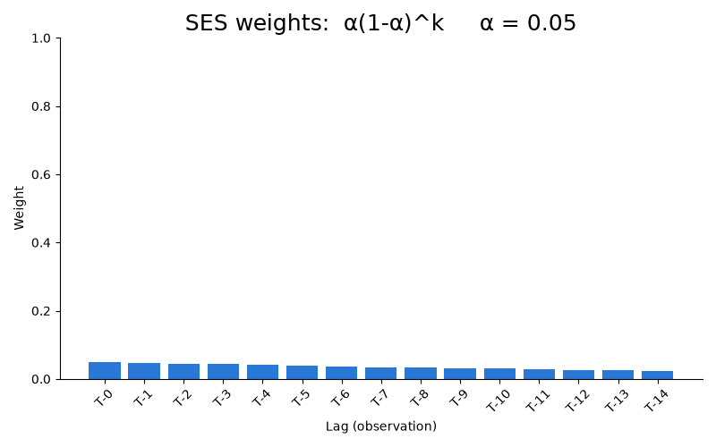

## SES : *specify*

- The *SES* model can be written in two forms - (i) *weighted average*, and (ii) *component*.
- The *weighted average form* is simple:

  $$\begin{aligned}
  \hat{y}_{T+1|T} &= \alpha y_T + \alpha(1-\alpha) y_{T-1} + \alpha(1-\alpha)^2 y_{T-2} + \dots + \alpha(1-\alpha)^{T-1} y_{1} \\
  &= \alpha y_T + (1-\alpha) \color{red}{[\alpha y_{T-1} + \alpha(1-\alpha) y_{T-2} + \dots + \alpha(1-\alpha)^{T-2} y_{1}]} \\
  &= \alpha y_T + (1-\alpha) \color{red}{\hat{y}_{T|T-1}}
  \end{aligned}$$
- So current forecast is the weighted average of the past true value and the past forecast.
- The smoothing parameter $0\leq\alpha\leq1$ controls how much we trust the past forecast.
- We can obtain the forecast by using recursion relations.

## SES : *weighted average form*

- Start from the first time point : let $\hat{y}_1 = l_0$.
- Continue :
  $$\begin{align}
  \hat{y}_{2|1} &= \alpha y_2 + (1-\alpha) \hat{y}_1 \\
  &= \alpha y_2 + (1-\alpha) l_o \\
  \hat{y}_{3|2} &= \alpha y_3 + (1-\alpha) \hat{y}_{2|1} \\
  &= \alpha y_3 + \alpha(1-\alpha) y_2 + (1-\alpha)^2 l_0\\
  &\vdots \\
  \hat{y}_{T+1|T} &= \alpha y_T + (1-\alpha) \hat{y}_{T|T-1} \\
  \hat{y}_{T+1|T} &= \sum_{j=0}^{T-1} \alpha(1-\alpha)^j y_{T-j} + \color{red}{(1-\alpha)^T} l_0
  \end{align}$$
- End: The last term in red for large $T$ becomes negligible, and hence we can ignore it.

## SES: *component form*

- An alternative representation known as *component form* for the SES comprises of two equations:
  $$\color{red}{\text{Forecast equation}}: \quad \hat{y}_{t+h|t} = l_t \\
  \color{red}{\text{Level equation}}: \quad l_t = \alpha y_t + (1-\alpha)l_{t-1},$$
  where $l_t$ is the level (smoothed value) of the time series at time $t$.
- The *forecast equation* shows the forecast value at time $t+h$ estimated at $t$.
- The *level equation* shows the estimated level of the series at each time $t$.
- For the SES, component form is not particularly useful, but it becomes quite handy when we consider trend or seasonality components in the time series.

## SES : *estimate*

- A natural question is - how do we optimize the choice of $\alpha$?
- One direct way is to have a *subjective* choice for it based on past experience.
- The *objective* way however, is to rely on statistical techniques like minimizing the Sum of Squared errors:
  $$SSE = \sum_{t=1}^{T}(y_t - \hat{y}_{t|t-1})^2 = \sum_{t=1}^{T} e_t^2$$
- The optimization above requires non-linear methods to solve the optimal value of parameters.
- In python, there is a direct way to do this that we will learn in the practical session.

## ETS

- Recall that a time series can be decomposed into *trend*, *seasonal* and *noise* components.
- The SES is model is simple, but it is *only applicable* to time series *without trend* or *seasonality*.
- In real scenarios time series often have the other components.
- Based on which component is present, we can still model it using exponential smoothing using it’s different versions.
- That’s why the whole family of exponential smoothing models are called *ETS* models (*E*rror, *T*rend, *S*easonal).

## ETS : *specify*

The general component form of the ETS model is:

$$\hat{y}_{t+h|t} = l_t * hb_t * s_{t+h-m(k+1)}$$

where:

- $*$: multiplicative / additive operator,
- $l_t$: estimate of the **level** at time $t$,
- $b_t$: estimate of the **trend** (slope) at time $t$,
- $s_t$: estimate of the **seasonal** component at time $t$,
- $m$: the **seasonal period** (e.g., $m = 12$ for monthly, $m = 4$ for quarterly data).
- $k$: the integer part of $(h-1)/m$, i.e.,

$$k = \left\lfloor \frac{h-1}{m} \right\rfloor$$

## ETS: taxonomy

- Based on the additive or multiplicative assumptions on the Trend and Seasonality components, we can classify the ETS model into many types.

| Seasonality Trend | None | Additive | Multiplicative |
| --- | --- | --- | --- |
| None | (N,N) | (N,A) | (N,M) |
| Additive | (A,N) | (A,A) | (A,M) |
| Damped | (Ad,N) | (Ad,A) | (Ad,M) |

- Among these the most important ETS models are:
  - $(A,N)$ : Holt’s linear method
  - $(A,A)$ : Additive Holt-Winters’ method
  - $(A,M)$ : Multiplicative Holt-Winters’ method
  - $(A_d,A)$ : Holt-Winters’ damped method
- In this lecture, we will discuss the additive and multiplicative Holt-Winters’ methods.

## Additive Holt-Winters’ Method (A,A)

- **Component form**:
  $$\color{red}{\text{Forecast equation:}}\quad \hat{y}_{t+h|t} = l_t + hb_t + s_{t+h-m(k+1)}\\
  \color{red}{\text{Level equation:}}\quad l_t = \alpha(y_t-s_{t-m}) + (1-\alpha)(l_{t-1}+b_{t-1})\\
  \color{red}{\text{Trend equation:}}\quad b_t = \beta^*(l_t-l_{t-1}) + (1-\beta^*)b_{t-1}\\
  \color{red}{\text{Seasonal equation:}}\quad s_t = \gamma(y_t - l_{t-1} - b_{t-1}) + (1-\gamma)s_{t-m}$$
  where:
- $0\leq\alpha\leq1$ is the smoothing parameter for the level,
- $0\leq\beta^*\leq1$ is the smoothing parameter for the trend,
- $0\leq\gamma\leq1$ is the smoothing parameter for the seasonality,
- $k = \left\lfloor \frac{h-1}{m} \right\rfloor$ ensures that the estimates of the seasonal indices used in forecasting come from the final year of the sample.

## Additive Holt-Winters’ Method (A,A)

- **Component form**:
  $$\color{red}{\text{Forecast equation:}}\quad \hat{y}_{t+h|t} = l_t + hb_t + s_{t+h-m(k+1)}\\
  \boxed{\color{red}{\text{Level equation:}}\quad l_t = \alpha(y_t-s_{t-m}) + (1-\alpha)(l_{t-1}+b_{t-1})}\\
  \color{red}{\text{Trend equation:}}\quad b_t = \beta^*(l_t-l_{t-1}) + (1-\beta^*)b_{t-1}\\
  \color{red}{\text{Seasonal equation:}}\quad s_t = \gamma(y_t - l_{t-1} - b_{t-1}) + (1-\gamma)s_{t-m}$$
- The level equation shows that the level component $l_t$ is a weighted average between:
  - the current observation adjusted by seasonality $(y_t-s_{t-m})$ and
  - the forecast without the seasonality $(l_{t-1}+b_{t-1})$.

## Additive Holt-Winters’ Method (A,A)

- **Component form**:
  $$\color{red}{\text{Forecast equation:}}\quad \hat{y}_{t+h|t} = l_t + hb_t + s_{t+h-m(k+1)}\\
  \color{red}{\text{Level equation:}}\quad l_t = \alpha(y_t-s_{t-m}) + (1-\alpha)(l_{t-1}+b_{t-1})\\
  \boxed{\color{red}{\text{Trend equation:}}\quad b_t = \beta^*(l_t-l_{t-1}) + (1-\beta^*)b_{t-1}}\\
  \color{red}{\text{Seasonal equation:}}\quad s_t = \gamma(y_t - l_{t-1} - b_{t-1}) + (1-\gamma)s_{t-m}$$
- The trend equation shows that the trend component $b_t$ is a weighted average between:
  - the estimated trend $(l_t-l_{t-1})$ and
  - the previous estimate of the trend $b_{t-1}$.

## Additive Holt-Winters’ Method (A,A)

- **Component form**:
  $$\color{red}{\text{Forecast equation:}}\quad \hat{y}_{t+h|t} = l_t + hb_t + s_{t+h-m(k+1)}\\
  \color{red}{\text{Level equation:}}\quad l_t = \alpha(y_t-s_{t-m}) + (1-\alpha)(l_{t-1}+b_{t-1})\\
  \color{red}{\text{Trend equation:}}\quad b_t = \beta^*(l_t-l_{t-1}) + (1-\beta^*)b_{t-1}\\
  \boxed{\color{red}{\text{Seasonal equation:}}\quad s_t = \gamma(y_t - l_{t-1} - b_{t-1}) + (1-\gamma)s_{t-m}}$$
- The seasonal equation shows that the seasonal component $s_t$ is a weighted average between:
  - the current seasonal index $(y_t-l_{t-1}-b_{t-1})$ and
  - seasonal index of the same season in last cycle ($m$ time periods ago) $s_{t-m}$.
- For simplicity we can write the seasonal component as:
  $$s_t = \gamma^*(y_t - l_t) + (1-\gamma^*)s_{t-m}$$

## Multiplicative Holt-Winters’ Method (A,M)

- **Component form**:
  $$\color{red}{\text{Forecast equation:}}\quad \hat{y}_{t+h|t} = (l_t + hb_t) s_{t+h-m(k+1)}\\
  \color{red}{\text{Level equation:}}\quad l_t = \alpha(\frac{y_t}{s_{t-m}}) + (1-\alpha)(l_{t-1}+b_{t-1})\\
  \color{red}{\text{Trend equation:}}\quad b_t = \beta^*(l_t-l_{t-1}) + (1-\beta^*)b_{t-1}\\
  \color{red}{\text{Seasonal equation:}}\quad s_t = \gamma(\frac{y_t}{l_{t-1} + b_{t-1}}) + (1-\gamma)s_{t-m}$$
- Similar to the additive form, the multiplicative model comes in the seasonality part.
- Subtractions related to the seasonal part gets replaced with divisions.

## ETS: *estimate*

- As mentioned for *SES*, the estimation of ETS models are also done by using the least squares method.
- Another alternative is to use the maximum likelihood estimation (*MLE*) for the different parameters of the model by minimizing *AIC* or *BIC*.
- Usually some of these parameters are restricted, but for simplicity we skip it in the lecture.
- the python package we will be using takes care of this internally.

## ETS: *forecast*

- *Point forecasts* are obtained by
  - iterating the equations for $t = T+1,\dots,T+h$
  - setting errors to $0$ for all the future time steps.
- For ETS(M,A,N), $y_{T+1} = (l_t+b_t)(1+\epsilon_{T+1})$ which implies, $\hat{y}_{T+1|T} = l_T+b_T$.
- To obtain *prediction intervals*, the following form is used,
  $$\hat{y}_{T+1|T} \pm c\sigma_h$$
  where $c:\text{coverage probability}$ and $\sigma_h^2:\text{forecast variance}$.
- For $95%$ prediction intervals, $c=1.96$; similarly other values of $c$ depending on the prediction interval can be obtained from the standard normal table.
- Estimating $\sigma_h^2$ is complicated and the python package will take care of that.

## ARIMA models

- Along with Exponential smoothing, ARIMA provides the other widely used approach to forecasting using univariate statistical models.
- In the previous lectures, you have learned about *stationary time series*.
- The statistical properties of a stationary time series $\{y_t\}$ doesn’t depend on the time at which the series is observed, i.e., $\forall s$, the distribution of $(y_t,\dots,y_{t+s})$ does not depend on $t$.
- Among the time series shown in the next slide can you tell which of the following are stationary?

## Which of the following are stationary?

[figure not shown]

Examples of time series data from different domains

## Differencing

- In the previous example, notice that the plots of (b) and (c) are coming from the same time series; and so are plots of (f) and (g).
- However, only (c) and (g) were stationary.
- This is one way to make a non-stationary time series **with varying mean** stationary - by computing differences between consecutive observations.
- Remember the *level equation*s in ETS?
- Differencing helps to stabilize the mean by removing the trend and seasonality in the level of a time series.

## Differencing

- The differenced series is written as,
  $$y_t' = y_t - y_{t-1}$$
- Differencing can be done consecutively, until we reach a differenced level that looks stationary.
  $$y_t'' = y'_t - y'_{t-1}$$
  …and so on.
- With each level of differencing, we lose one observation.
- **Seasonal differencing** : Differencing done between an observation and the previous observation from the same season.
  $$y_t' = y_t - y_{t-m}, \quad m:\text{no. of seasons}$$

## Unit root test

- A natural question is, how to know if differencing is required, or more generally which is the order at which we can stop differencing further?
- This can be decided using certain statistical hypotheses tests known as unit root tests.
- There are a few different options for the unit root tests with different assumptions.
- In our experiments we will use the KPSS test where the null hypothesis is $H_0:y_t\text{ is stationary}$ against the alternative $H_1:y_t\text{ is not stationary}$.
- In the practical session, we will see in details how to use this test.

## Backshift operator

- The seasonal differences are also called *lag-*$m$ differences, and the usual differences are called lag-$1$ differences.
- *Backshift* or *Lag operator* is an useful tool to write the differenced series.
  $$By_t = y_{t-1}$$
- $B$ shifts the data back $1$ period. Applying it twice will shift the data by $2$ periods.
  $$B^2y_t = B(By_t) = y_{t-2}$$
- A first differenced series can be written as,
  $$y'_t = y_t - y_{t-1} = y_t - By_t = (1-B)y_t$$
- It is easy to show that a $d$-differenced series becomes $(1-B)^dy_t$.

## ARIMA: *specify*

- ARIMA (**A**uto**R**egressive **I**ntegrated **M**oving **A**verage) models have three components:
  - **AR**: a linear combination of the past $p$ lagged values of the differenced series.
  - **MA**: a linear combination of the past $q$ lagged white noise errors.
  - **I**: the order of the differenced series.
- The full model is written as:
  $$y_t' = c + \sum_{i=1}^{p}\phi_iy_{t-i}'+ \sum_{j=1}^{q}\theta_j\epsilon_{t-j}'+\epsilon_t$$
  and called an *ARIMA(*$p,d,q$) model where $p:\text{order of the AR part}$, $q:\text{order of the MA part}$, and $d:\text{order of the difference}$.

## ARIMA: *specify*

- In the backshift notation, we can write the full model as,
  $$\underbrace{(1 - \phi_1B - \dots - \phi_pB^p)}_{AR(p)}\color{red}{\underbrace{(1-B)^d}_{d \text{ differences}}} y_t = c + \underbrace{(1 + \theta_1B + \dots + \theta_qB^q)}_{MA(q)}\epsilon_t$$
- The following are the special cases of ARIMA($p,d,q$).

| Special case | ARIMA($p,d,q$) |
| --- | --- |
| White Noise | ARIMA($0,0,0$), $c=0$ |
| Random Walk | ARIMA($0,1,0$), $c=0$ |
| Random Walk with drift | ARIMA($0,1,0$) |
| Autoregression | ARIMA($p,0,0$) |
| Moving Average | ARIMA($0,0,q$) |

## AR($p$) model

- These are ARIMA($p,0,0$) models:
  $$y_t = c + \phi_1y_{t-1} + \dots + \phi_py_{t-p} + \epsilon_t$$

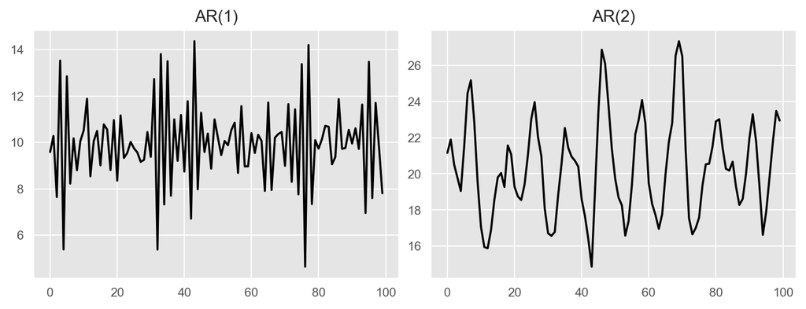

[fppy chapter 9](https://otexts.com/fpppy/09-arima.html#fig-arp)

- *Stationarity conditions*:
  - AR(1) : $-1 < \phi_1 < 1$
  - AR(2) : $-1 < \phi_2 < 1, \space \phi_1+\phi_2<1, \space \phi_2 - \phi_1 < 1$

## MA($q$) model

- These are ARIMA($0,0,q$) models:
  $$y_t = c + \epsilon_t + \theta_1\epsilon_{t-1} + \dots + \theta_q\epsilon_{t-q}$$

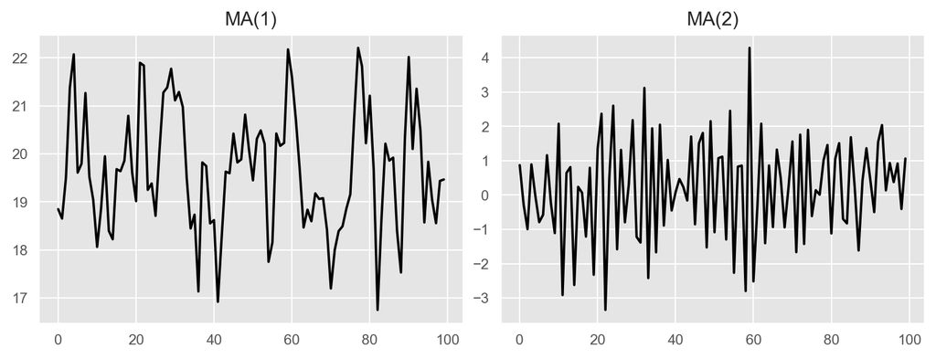

[fppy chapter 9](https://otexts.com/fpppy/09-arima.html#fig-maq)

- *Invertibility conditions*:
  - MA(1) : $-1 < \theta_1 < 1$
  - MA(2) : $-1 < \theta_2 < 1, \space \phi_1+\phi_2>-1, \space \phi_2 - \phi_1 < 1$

## MA($q$) model

- Try to prove the following theorem:

*“Any stationary AR(*$p$) model can be written as an MA($\infty$) model”

- If we impose the invertibility constraints on the MA($q$) process, then the converse is also true - it can be written as a AR($\infty$) model, and the MA model is known as *invertible*.
- For MA($1$), $y_t = \epsilon_t+\theta_1\epsilon_{t-1}$, and in its AR($\infty$) representation,
  $$\epsilon_t = \sum_{j=0}^{\infty} (-\theta_1)^jy_{t-j}$$
- Intuitively, since $(\theta_1)^j$’s are weights, it is only sensible that the most recent observations gets more weights than the ones in the distant past ($|\theta_1|<1$).

## ARIMA: *estimate*

- For ARIMA models, *AIC* and *BIC* are useful to determine the order ($p$, $d$, and $q$).
- We don’t need to worry much about this part; the python package we will be using for fitting the forecasting models will automatically give us the order of the ARIMA using the minimized AIC or BIC.
- Once the order is determined, they are estimated using the maximum likelihood estimation (*MLE*) procedure.
- For ARIMA models, these results are similar to the ones obtained by using the least squares method by minimizing $\sum_{t=1}^{T}\epsilon_t^2$.

## ARIMA: *forecast*

- To obtain *point forecasts* the following three steps are required:
  - Expand the equation such that $y_t$ is on LHS and all other terms are on RHS
  - Rewrite the equation by replacing $t$ with $T+h$
  - On RHS, replace future observations with their forecasts, future errors with $0$, and past errors with corresponding residuals.
- Again, the forecasting package takes care of this.
- To understand this step better and to understand how to produce prediction intervals over these point forecasts refert to [fpppy 9.8](https://otexts.com/fpppy/09-arima.html#sec-arima-forecasting).

## Exercise

- In the practical session we will do the following tasks:
  - Convert an extracted time series data into tidy dataframe.
  - How to use *statsforecast* package.
  - AutoETS and AutoARIMA for forecasting.